# Practical machine learning project

Yue Dai

2017-06-30

## Exexutive Summary

The data of the project is collected from accelerometers on the belt, forearm, arm, and dumbell of 6 participants. They were asked to perform barbell lifts correctly and incorrectly in 5 different ways. This project is to predict the manner in which 6 participants did the exercise. This is the “classe” variable in the training set. The machine learning algorithm described here is applied to the 20 test cases available in the test data.The data for this project come from http://groupware.les.inf.puc-rio.br/har. . The content of the project includes several parts:

1. Load the data and preprocess the data
2. Perform basic exploratory data analysis
3. Select machine learning algorithm
4. Exam the selected model to define the best one

## Exporatory Data Analysis

1. Load the necessary libraries

```r
library(lattice)
library(ggplot2)
library(caret)
library(rpart)
library(rpart.plot)
library(randomForest)
library(corrplot)
set.seed(2017)
```

2. Load and clean data

```r
training <- read.csv("https://d396qusza40orc.cloudfront.net/predmachlearn/pml-training.csv")
testing <- read.csv("https://d396qusza40orc.cloudfront.net/predmachlearn/pml-testing.csv")
dim(training) # Display the information of the data
```

```
## [1] 19622   160
```

```r
## head(training)
```

The training dataset has 19622 observations and 160 variables, and the testing data set contains 20 observations and the same variables as the training set. But there is a lot of missing value (NA), so we delete those columns in the training and testing data set.

```r
# remove variable with missing values
training <- training[, colSums(is.na(training)) == 0]

# remove variavle with Nearly Zero Variance
NZV <- nearZeroVar(training)
training <- training[, -NZV]
dim(training)
```

```
## [1] 19622    59
```

We also remove the participant names and the time related data, because we won’t use them.

```r
training <- training[, -(1:5)]
dim(training)
```

```
## [1] 19622    54
```

With the cleaning process above, the number of variables for the analysis has been reduced to 54.

3. Split the traning dataset

The training dataset is then partitioned in two parts: a Training set (70% of the data) and a Test set (with the remaining 30%) for the validations. The original testing dataset is not changed and will only be used for the quiz results generation.

```r
set.seed(0629)
inTrain <- createDataPartition(training$classe, p=0.7, list=FALSE)
TrainSet <- training[inTrain, ]
TestSet  <- training[-inTrain, ]
```

4. Analyze correlation

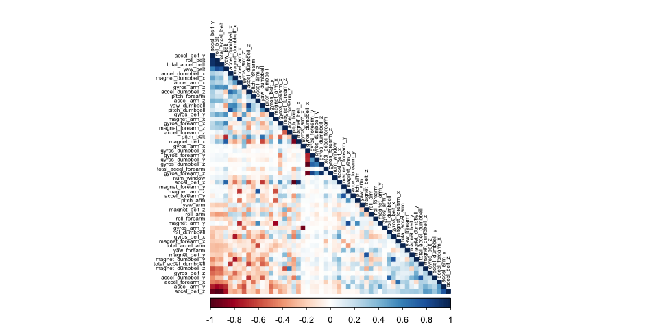

```r
cormatrix <- cor(training[, -54])
corrplot(cormatrix, order = "FPC", method = "color", type = "lower",
         tl.cex = 0.5, tl.col = rgb(0,0,0))
```

The dark colors indicates the high correlation variables. As the analyzing plot shown, the correlations are few. We can go further to select models.

## Prediction model selection

In order to avoid overfitting and to reduce out of sample errors, TrainControl is used to perform 3-fold cross validation. We use **SVM** (“svmRadial”), **Boosted Tree** (“gbm”)and **Random Forests** (“rf”) to predict the outcome.

```r
ctrl <- trainControl(method = "cv", number = 3)
library(kernlab)
modSVM <- train(classe ~ ., data = TrainSet, method = "svmRadial",
                   trControl = ctrl)
print(modSVM, digits = 4)
```

```
## Support Vector Machines with Radial Basis Function Kernel
##
## 13737 samples
##    53 predictor
##     5 classes: 'A', 'B', 'C', 'D', 'E'
##
## No pre-processing
## Resampling: Cross-Validated (3 fold)
## Summary of sample sizes: 9157, 9158, 9159
## Resampling results across tuning parameters:
##
##   C     Accuracy  Kappa
##   0.25  0.8545    0.8161
##   0.50  0.8883    0.8587
##   1.00  0.9190    0.8974
##
## Tuning parameter 'sigma' was held constant at a value of 0.0134079
## Accuracy was used to select the optimal model using  the largest value.
## The final values used for the model were sigma = 0.01341 and C = 1.
```

```r
library(gbm)
library(survival)
library(plyr)
library(splines)
library(parallel)
modGBM <- train(classe ~ ., data = TrainSet, method = "gbm",
                verbose=FALSE, trControl = ctrl)
print(modGBM, digits = 4)
```

```
## Stochastic Gradient Boosting
##
## 13737 samples
##    53 predictor
##     5 classes: 'A', 'B', 'C', 'D', 'E'
##
## No pre-processing
## Resampling: Cross-Validated (3 fold)
## Summary of sample sizes: 9158, 9159, 9157
## Resampling results across tuning parameters:
##
##   interaction.depth  n.trees  Accuracy  Kappa
##   1                   50      0.7599    0.6953
##   1                  100      0.8321    0.7874
##   1                  150      0.8709    0.8366
##   2                   50      0.8847    0.8539
##   2                  100      0.9396    0.9235
##   2                  150      0.9623    0.9523
##   3                   50      0.9316    0.9135
##   3                  100      0.9703    0.9624
##   3                  150      0.9857    0.9819
##
## Tuning parameter 'shrinkage' was held constant at a value of 0.1
##
## Tuning parameter 'n.minobsinnode' was held constant at a value of 10
## Accuracy was used to select the optimal model using  the largest value.
## The final values used for the model were n.trees = 150,
##  interaction.depth = 3, shrinkage = 0.1 and n.minobsinnode = 10.
```

```r
modRF <- train(classe ~ ., data = TrainSet, method = "rf",
                   trControl = ctrl)
print(modRF, digits = 4)
```

```
## Random Forest
##
## 13737 samples
##    53 predictor
##     5 classes: 'A', 'B', 'C', 'D', 'E'
##
## No pre-processing
## Resampling: Cross-Validated (3 fold)
## Summary of sample sizes: 9158, 9158, 9158
## Resampling results across tuning parameters:
##
##   mtry  Accuracy  Kappa
##    2    0.9915    0.9892
##   27    0.9957    0.9946
##   53    0.9938    0.9922
##
## Accuracy was used to select the optimal model using  the largest value.
## The final value used for the model was mtry = 27.
```

## Prediction model analysis

```r
predSVM <- predict(modSVM, TestSet)
predGBM <- predict(modGBM, TestSet)
predRF <- predict(modRF, TestSet)
```

```r
PredictionModel <- c("SVM", "GBM", "RF")
c2 <- confusionMatrix(TestSet$classe, predSVM)$overal[1]
c3 <- confusionMatrix(TestSet$classe, predGBM)$overall[1]
c4 <- confusionMatrix(TestSet$classe, predRF)$overall[1]
Accuracy <- c(c2, c3,c4)
df <- data.frame(PredictionModel, Accuracy)
df
```

```
##   PredictionModel  Accuracy
## 1             SVM 0.9318607
## 2             GBM 0.9874257
## 3              RF 0.9969414
```

## Prediction on testing dataset

We choose the Random Forest model to predict the testing dataset as shown below.

```r
predtest <- predict(modRF, testing)
predtest
```

```
##  [1] B A B A A E D B A A B C B A E E A B B B
## Levels: A B C D E
```